# Practical Machine Learning Project

Me

21 Juli 2018

```r
library(caret)
training <- read.csv("pml-training.csv")
testing <- read.csv("pml-testing.csv")

noNAtraining <- subset(training, select=colMeans(is.na(training)) == 0)

str(noNAtraining)
```

```
## 'data.frame':    19622 obs. of  93 variables:
##  $ X                      : int  1 2 3 4 5 6 7 8 9 10 ...
##  $ user_name              : Factor w/ 6 levels "adelmo","carlitos",..: 2 2 2 2 2 2 2 2 2 2 ...
##  $ raw_timestamp_part_1   : int  1323084231 1323084231 1323084231 1323084232 1323084232 1323084232 1323084232 1323084232 1323084232 1323084232 ...
##  $ raw_timestamp_part_2   : int  788290 808298 820366 120339 196328 304277 368296 440390 484323 484434 ...
##  $ cvtd_timestamp         : Factor w/ 20 levels "02/12/2011 13:32",..: 9 9 9 9 9 9 9 9 9 9 ...
##  $ new_window             : Factor w/ 2 levels "no","yes": 1 1 1 1 1 1 1 1 1 1 ...
##  $ num_window             : int  11 11 11 12 12 12 12 12 12 12 ...
##  $ roll_belt              : num  1.41 1.41 1.42 1.48 1.48 1.45 1.42 1.42 1.43 1.45 ...
##  $ pitch_belt             : num  8.07 8.07 8.07 8.05 8.07 8.06 8.09 8.13 8.16 8.17 ...
##  $ yaw_belt               : num  -94.4 -94.4 -94.4 -94.4 -94.4 -94.4 -94.4 -94.4 -94.4 -94.4 ...
##  $ total_accel_belt       : int  3 3 3 3 3 3 3 3 3 3 ...
##  $ kurtosis_roll_belt     : Factor w/ 397 levels "","0.000673",..: 1 1 1 1 1 1 1 1 1 1 ...
##  $ kurtosis_picth_belt    : Factor w/ 317 levels "","0.006078",..: 1 1 1 1 1 1 1 1 1 1 ...
##  $ kurtosis_yaw_belt      : Factor w/ 2 levels "","#DIV/0!": 1 1 1 1 1 1 1 1 1 1 ...
```

[output cut: 79 more lines]

Looking at the output of the remaining data, there are still variables that do not contain much information. These columns are removed manually. The remaining data set is split into a training and a test set for model building.

```r
trainData <- noNAtraining[,c(2,8,9,10,11,21:42, 49:51,61:73,83:93)]

set.seed(455667)
inTrain <- createDataPartition(trainData$classe, p=0.7, list=FALSE)
SubTrain <- trainData[inTrain,]
SubTest <- trainData[-inTrain,]
dim(SubTrain)
```

```
## [1] 13737    54
```

```r
dim(SubTest)
```

```
## [1] 5885   54
```

## Random forest

A random forest model is trained using the SubTrain data.

```r
tc <- trainControl(method="cv", number=5)
modrf <- train(classe ~ ., method = "rf", data=SubTrain, trControl=tc, verbose=FALSE)
```

Calculate the confusion matrix and the accuracy of the model.

```r
predrf <- predict(modrf, SubTest)
cmrf <- confusionMatrix(SubTest$classe,predrf)
cmrf$table
```

```
##           Reference
## Prediction    A    B    C    D    E
##          A 1673    1    0    0    0
##          B    7 1126    6    0    0
##          C    0    6 1018    2    0
##          D    0    0    5  959    0
##          E    0    0    3    2 1077
```

```r
cmrf$overall
```

```
##       Accuracy          Kappa  AccuracyLower  AccuracyUpper   AccuracyNull
##      0.9945624      0.9931215      0.9923324      0.9962778      0.2854715
## AccuracyPValue  McnemarPValue
##      0.0000000            NaN
```

The out of sample error is 100% - accuracy = 0.54 %.

## Classification tree

As the calculation of the random forest model was very time consuming, also a simple classification tree is calculated.

```r
modct <- train(classe ~ ., method = "rpart", data=SubTrain)
```

Plot the classifiaction tree.

```r
library(rattle)
```

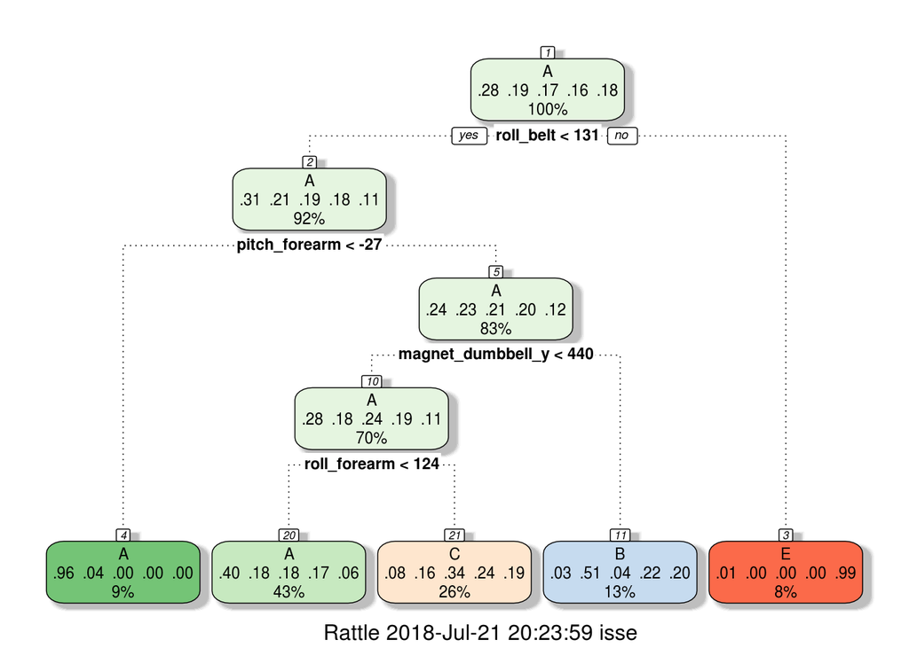

```r
fancyRpartPlot(modct$finalModel)
```

Calculate the confusion matrix and the accuracy of the model.

```r
predct <- predict(modct, SubTest)
cmct <- confusionMatrix(SubTest$classe,predct)
cmct$table
```

```
##           Reference
## Prediction    A    B    C    D    E
##          A 1533   25  112    0    4
##          B  496  350  293    0    0
##          C  488   28  510    0    0
##          D  442  181  341    0    0
##          E  162  134  299    0  487
```

```r
cmct$overall
```

```
##       Accuracy          Kappa  AccuracyLower  AccuracyUpper   AccuracyNull
##      0.4893798      0.3317599      0.4765311      0.5022390      0.5303314
## AccuracyPValue  McnemarPValue
##      1.0000000            NaN
```

The out of sample error is 100% - accuracy = 51,06%.

## Apply best model to test data

As the results of the random forest model were much better than the results of the classification tree, the test data will be processed with the random forest model.

```r
predict(modrf, testing)
```

```
##  [1] B A B A A E D B A A B C B A E E A B B B
## Levels: A B C D E
```